# Midpoint Deliverable

# Introduction

This project will perform analysis on League of Legends data. It will provide an in-depth analysis of a particular player’s recent statistics based upon their most recent 100 games, as well as provide more meta-level analysis comparing trends of the player base as a whole over a larger period of time. Any such insights obtained here can very easily be recreated for any player given the flexibility of the API.

# Data

For this midpoint deliverable report, BoxBox’s player data is chosen to be analyzed. This is because it appears he hasn’t played recently, so data shouldn’t be changing much from the time this report is written to when it’s graded assuming he doesn’t suddenly start playing, and he’s a relatively high-level player which theoretically reduces the impact luck may have on the game outcomes, and increases dependence of quantifiable in-game factors to match outcomes leading to more accurate analysis.

## Summary of Available Data

The data retrieved and utilized includes various back-end data, such as translating player's name into an encrypted summonerID which is then used in further API requests for more data, or a list of match ID's to get detailed information for each match. Basic ranked data had a few elements, including player name as formatted in-game, league (e.g. Diamond), position in the league (e.g. Diamond 1), and league points (e.g. 97 LP). With the player name, one can get the account ID, which lists the most recent 100 matches. From this list of 100 rows, one can use the game ID to get detail about each match. Each match returns JSON of 13 top-level items. The most relevant item is nested 3 levels deep, which are statistics for one specific player in the game, which has 104 values, such as whether they won, number of turrets killed, etc. This lets one create a table like the table below, with statistics from each match utilized for analysis

BoxBox is currently ranked diamond I with 97 LP. In the last 100 games, their winrate has been 55%. Their most played champion is Riven.

#### Per-Champion Player Statistics for BoxBox

[output not shown]

A summary of their per-character stats split into games won and lost can be seen in the above table. Statistics were split into each champion played, and further into whether those games played were won or lost, as averaging together statistics for vastly different roles would be unreasonable, and splitting games by whether they were won or lost allows for the comparison of which factors appear to vary between won and lost games.

# Preliminary Charts

## Frequently Played Champions

[figure not shown]

For example in analyzing BoxBox’s chart, one can see that he has played Riven and Fiora significantly more consistently than the others, and has a significantly positive winrate with those champions. One can also see that with champions played less often, the winrate appears to be more volatile, which makes intuitive sense when taking into account low sample size to calculate winrate, and being less practiced on those champions.

## Comparison of Won vs. Lost Games

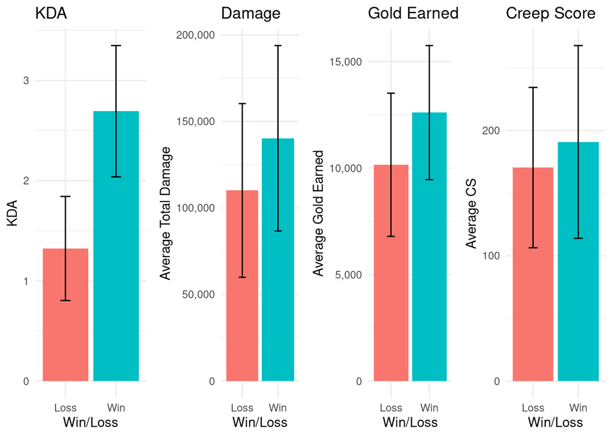

These charts provide a comparison of average player stats in the games BoxBox has won and lost. One may gain insight into possible avenues of improvement from these stats. For example, if one’s CS is varying a lot between the games they lost and won in but their KDA is not, that may suggest that an effective way to improve one’s chances of improving would be to focus on CS rather than improving their KDA. These stats are highly contextual, however, and should only provide an overview to how differently a player’s stats are in the games they won compared to those that they lost. The error bars are the standard deviation for the stats.

In BoxBox’s case in particular, some example insights may be gained from these graphs. The CS difference between games won and lost are relatively minimal whereas KDA has quite a large variance, which may suggest that BoxBox isn’t missing a lot of CS while in lane as a lower-ranked player might, and thus causing them to lose games. Instead, there appear to be relatively similar amount of CS, suggesting that other factors, such as early kills or deaths snowballing to more kills or deaths, may be more important in deciding whether BoxBox’s game will end up in a win or loss for them.

## Games Played vs. Time Started

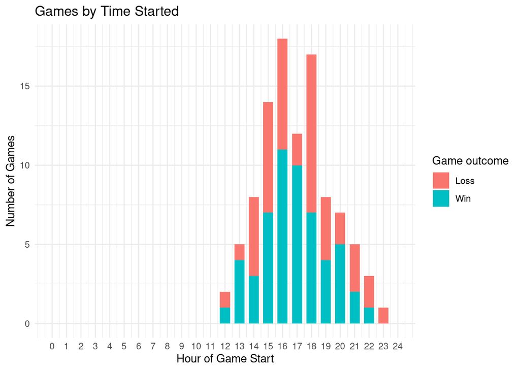

This chart provides an overview of the time of day a player plays their most recent games, as well as the outcome of the games. This might be useful in seeing if a particular time of day is particularly favorable or unfavorable for a player.